# Women's E-Commerce Clothing Reviews

## About Dataset

#### Context

This is a Women’s Clothing E-Commerce dataset revolving around the reviews written by customers. Its nine supportive features offer a great environment to parse out the text through its multiple dimensions. Because this is real commercial data, it has been anonymized, and references to the company in the review text and body have been replaced with “retailer”.

#### This dataset includes **23486 rows** and **10 columns**. Each row corresponds to a customer review, and includes the variables:

- **ClothinID**: Integer Categorical variable that refers to the **specific piece** being reviewed.
- **Age**: Positive Integer variable of the **reviewers age**.
- **Title**: String variable for the **title of the review**.
- **Review Text**: String variable for the **review body**.
- **Rating**: Positive Ordinal Integer variable for the **product score** granted by the customer from **1 Worst**, to **5 Best**.
- **Recommended IND**: Binary variable stating where the customer recommends the product where **1 is recommended**, **0 is not recommended**.
- **Positive Feedback Count**: Positive Integer documenting the **number** of other customers **who found this review positive**.
- **Division Name**: Categorical name of the **product high level division**.
- **Department Name**: Categorical name of the product **department name**.
- **Class Name**: Categorical name of the **product class name**.

## What was done in this notebook?

- 1. **Explore every features in the dataset;**
- 2. **Department Analysis;** (by **Age & Rate**)
- 3. **Text Analysis;** (by **Recommended or not**)
- 4. **Modeling** (using **BERT**)

## Outlines

- 1. Import Necessary Libraries
- 2. Univariate Analysis
  - 2.1. Explore Numeric Columns
    - 2.1.1. Age Distribution
    - 2.1.2. Rating & Recommended IND
    - 2.1.3. Positive Feedback Count
    - 2.1.4. Text Length by Recommended IND
  - 2.2. Categorical Columns
    - 2.2.1. Department Name & Class Name
    - 2.2.2. Text
- 3. Bivariate Analysis
  - 3.1. Age by Department
  - 3.2. Department by Rate
  - 3.3. Recommended IND by Rate
  - 3.4. Text by Recommended IND (Positive Adjectives)
- 4. Text Preprocessing
  - 4.1. Define Preprocessing Function
  - 4.2. Tokenization, Sequencing and Padding
- 5. Text Classification (BERT Model)
  - 5.1. Define Model
  - 5.2. Train Model
  - 5.3. Model Inference
    - 5.3.1. Restore Model
    - 5.3.2. Compare Each Scores : Accuracy, Precision, Recall, F1, AUC

# 1. Import Necessary Libraries

```python
import pandas as pd
import numpy as np
import os
import pickle
import random

# data visualization
import seaborn as sns
import matplotlib as mpl
import matplotlib.pyplot as plt
from plotly.offline import download_plotlyjs, init_notebook_mode , plot
from plotly.graph_objs import *
init_notebook_mode()
import plotly.express as px
import plotly.figure_factory as ff
import plotly.graph_objects as go
from plotly.subplots import make_subplots
from plotly.offline import plot
import missingno as msno
from wordcloud import WordCloud
import seaborn as sns
import squarify

# tensorflow
import tensorflow as tf

# transformers
from transformers import BertTokenizer
from transformers import TFBertForSequenceClassification

# nltk
import nltk
from nltk.util import ngrams
from nltk.corpus import stopwords
from nltk.tokenize import word_tokenize
from nltk.stem import WordNetLemmatizer

from bs4 import BeautifulSoup
import string
import re

# sklearn
from sklearn.model_selection import train_test_split
from sklearn.metrics import accuracy_score , precision_score , recall_score , f1_score , roc_auc_score
```

#### Read Dataframe, and explore data's shape & distribution of missing values & info:

```
Total Features:11; There are 5 features have missing values
Shape of DataFrame(before preprocess) : (23486, 11)
```

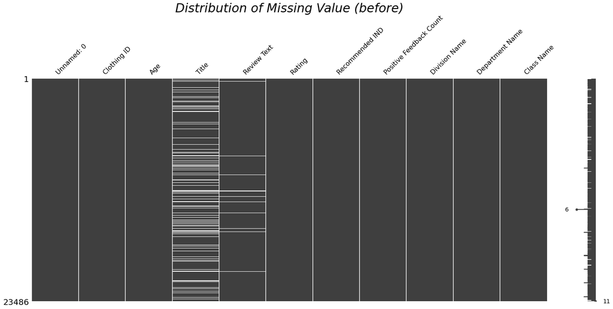

```python
df = pd.read_csv('./Womens Clothing E-Commerce Reviews.csv')
def missing_values_table(data):
    missing_value = data.isnull().sum()
    missing_value_percent = data.isnull().sum() / data.shape[0] * 100
    missing_value_table = pd.concat([missing_value , missing_value_percent] , axis = 1)
    missing_value_table = missing_value_table.rename(columns = {0 : 'Missing Values' , 1 : '% of Total Values'})
    missing_value_table.sort_values('% of Total Values' , ascending = False , inplace = True)
    print('Total Features:{}; There are {} features have missing values'.format(len(missing_value_table) , (missing_value_table['% of Total Values'] != 0).sum()))
    return missing_value_table.loc[missing_value_table['% of Total Values'] != 0]
missing_values_table(df)

print('Shape of DataFrame(before preprocess) : {}'.format(df.shape))
feature_nan = df.isnull().sum() / df.shape[0]

msno.matrix(df).set_title('Distribution of Missing Value (before)' , fontsize = 30 , fontstyle= 'oblique')
```

#### Cean data by dropping and creating new column.

```python
df.drop(['Unnamed: 0' , 'Clothing ID'] , axis = 1 , inplace = True)
df.dropna(subset = ['Review Text' , 'Division Name' , 'Department Name' , 'Class Name' , 'Title'] , inplace = True)
df['Text'] = df['Title'] + ' ' + df['Review Text']

df.drop(['Title' , 'Review Text' , 'Division Name'] , axis = 1 , inplace = True)
df = df.reset_index().drop('index' , axis = 1)
df['Text_Length'] = df['Text'].apply(len)
print('Shape of DataFrame(after preprocess) : {}'.format(df.shape))
```

```
Shape of DataFrame(after preprocess) : (19662, 8)
```

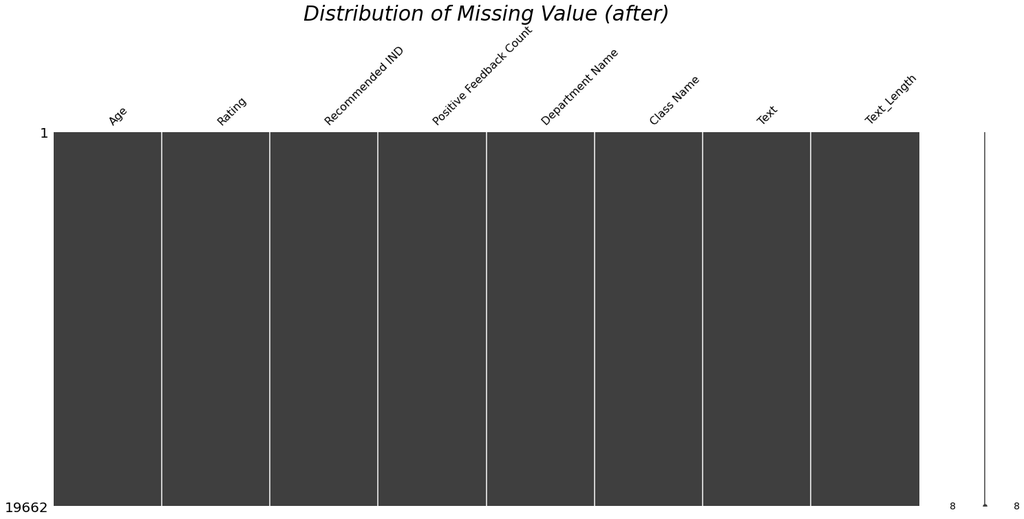

```python
msno.matrix(df).set_title('Distribution of Missing Value (after)' , fontsize = 30 , fontstyle= 'oblique')
feature_nan = df.isnull().sum() / df.shape[0]
```

```python
df.info() #  we got 8 columns: 5 numeric columns & 3 categorical columns.
```

```
<class 'pandas.core.frame.DataFrame'>
RangeIndex: 19662 entries, 0 to 19661
Data columns (total 8 columns):
 #   Column                   Non-Null Count  Dtype
---  ------                   --------------  -----
 0   Age                      19662 non-null  int64
 1   Rating                   19662 non-null  int64
 2   Recommended IND          19662 non-null  int64
 3   Positive Feedback Count  19662 non-null  int64
 4   Department Name          19662 non-null  object
 5   Class Name               19662 non-null  object
 6   Text                     19662 non-null  object
 7   Text_Length              19662 non-null  int64
dtypes: int64(5), object(3)
memory usage: 1.2+ MB
```

```python
def status(x) :
    return pd.Series([x.count() , x.min() , x.idxmin() , x.quantile(.25) , x.median(), x.quantile(0.75) ,
                      x.mean() , x.max() , x.idxmax() , x.mad() , x.var(), x.std() , x.skew() , x.kurt()] ,
                      index=['count' , 'min' , 'min_index' , '25%' , '50%' , '75%' , 'mean' , 'max' , 'max_index' , 'mad' , 'var' , 'std' , 'skew' , 'kurt'])

object_features = []
for col in df.columns:
    if df[col].dtypes == 'object':
        object_features.append(col)
number_feature = list(set(list(df.columns)).difference(set(object_features)))

number_describe = df[number_feature].apply(status)
object_describe = df[object_features].describe()
```

```python
number_describe.T.style.background_gradient(low = 0.2 , high = 0.5 , cmap = 'rocket_r')
```

|  | count | min | min_index | 25% | 50% | 75% | mean | max | max_index | mad | var | std | skew | kurt |
| --- | --- | --- | --- | --- | --- | --- | --- | --- | --- | --- | --- | --- | --- | --- |
| Positive Feedback Count | 19662.000000 | 0.000000 | 0.000000 | 0.000000 | 1.000000 | 3.000000 | 2.652477 | 122.000000 | 6050.000000 | 3.125654 | 34.038878 | 5.834285 | 6.339509 | 67.512044 |
| Rating | 19662.000000 | 1.000000 | 47.000000 | 4.000000 | 5.000000 | 5.000000 | 4.183145 | 5.000000 | 1.000000 | 0.902188 | 1.237043 | 1.112224 | -1.280191 | 0.706729 |
| Text_Length | 19662.000000 | 23.000000 | 11211.000000 | 217.000000 | 336.000000 | 496.000000 | 338.543739 | 557.000000 | 11265.000000 | 126.677905 | 20945.222923 | 144.724645 | -0.113424 | -1.270739 |
| Age | 19662.000000 | 18.000000 | 7417.000000 | 34.000000 | 41.000000 | 52.000000 | 43.260808 | 99.000000 | 6967.000000 | 9.999603 | 150.261562 | 12.258122 | 0.515632 | -0.139725 |
| Recommended IND | 19662.000000 | 0.000000 | 0.000000 | 1.000000 | 1.000000 | 1.000000 | 0.818177 | 1.000000 | 1.000000 | 0.297527 | 0.148771 | 0.385708 | -1.650001 | 0.722578 |

```python
object_describe.T
```

|  | count | unique | top | freq |
| --- | --- | --- | --- | --- |
| Department Name | 19662 | 6 | Tops | 8713 |
| Class Name | 19662 | 20 | Dresses | 5371 |
| Text | 19662 | 19658 | Love retailer bathing suits! Perfect fit and i... | 3 |

# 2. Univariate Analysis

#### We got 8 columns: 5 numeric columns & 3 categorical columns.

#### Mainly two parts in the section: Analysis on numeric columns; Analysis on categorical columns.

## 2.1. Explore Numeric Columns

#### Numeric Columns in the DataFrame:

- 1.Age
- 2.Rating
- 3.Recommended IND
- 4.Positive Feedback Count
- 5.Text_Length

#### Explore numeric columns in the dataset by plotting distplot, barplot.

## 2.1.1. Age Distribution

```python
# 1. distribution plot
hist_data = [df['Age']]
group_labels = ['Age Distribution']
fig1 = ff.create_distplot(hist_data , group_labels , show_hist = True , show_rug=False , colors = ['#b2182b' , '#2166ac'])
fig1.update_layout(xaxis_title = 'Age',
                   title = 'Age Distribution' ,
                   font = dict(size=17, family = 'Franklin Gothic') ,
                   template = 'simple_white')
fig1.show()

# 2. bar plot
age = df['Age'].value_counts().sort_index()
age = pd.DataFrame(age)
age['count'] = age['Age']
age.drop(['Age'] , axis = 1 , inplace = True)
age['age'] = age.index
age = age.reset_index(drop = True)
for i in range(0 , 10):
    age.loc[age['age'].between(i * 10 , i * 10 + 9 , 'left') , 'age_group'] = '{}-{}'.format(i * 10 , i * 10 + 9)

age_df = age.groupby('age_group').apply(lambda x : sum(x['count'])).reset_index()
age_df = age_df.sort_values(by = 'age_group' , ascending = True)
age_df = age_df.rename({0: 'count'} , axis=1)
fig2 = px.bar(x = age_df['age_group'],
              y = age_df['count'],
              text = age_df['count'],
              color = age_df['age_group'],
              color_discrete_sequence = px.colors.sequential.RdBu,
              template = 'simple_white',
              title = 'Age Bar Plot')

# Age of customer mostly distributed in the range of 30 to 59
fig2.update_traces(width = 0.7 , marker = dict(line = dict(color = '#000000' , width = 2)))
fig2.update_layout(xaxis_title = 'Age Range',
                   yaxis_title = 'count',
                   font = dict(size = 17 , family= ' Franklin Gothic'))

fig2.show()
```

[interactive chart not shown]

## 2.1.2. Rating & Recommended IND

```python
rating = df['Rating'].value_counts()
rating_pie = go.Pie(values = rating.values,
                    labels = rating.index,
                    marker = dict(colors = ['#fddbc7' , '#f4a582' , '#d6604d' , '#b2182b' , '#67001f']) ,
                                  title = 'Rating' ,
                                  titlefont = dict(size = 17))
layout = go.Layout(title = 'Rating' , font = dict(size = 17 , family= ' Franklin Gothic'))
fig1 = go.Figure(data = [rating_pie] , layout = layout)
fig1.show()

recommended = df['Recommended IND'].value_counts()
recommended_trace = go.Pie(values = recommended.values,
                           labels = recommended.index,
                           marker = dict(colors = ['#fddbc7' , '#f4a582']) ,
                                         title = 'Recommended IND' ,
                                         titlefont = dict(size = 17))
layout = go.Layout(title = 'Recommended IND' , font = dict(size = 17 , family= ' Franklin Gothic'))
fig2 = go.Figure(data = [recommended_trace] , layout = layout)
fig2.show()
```

[interactive chart not shown]

#### 1.Rating: 4 and 5 rates account about 77% of rating. 2.Recommended IND: About 82% products are recommended in the dataset.

## 2.1.3. Positive Feedback Count

```python
hist_data = [df['Positive Feedback Count']]
group_labels = ['Positive Feedback Count']

# 1. distribution plot
fig1 = ff.create_distplot(hist_data , group_labels ,show_hist = True , show_rug=False , colors = ['#b2182b'])
fig1.update_layout(xaxis_title = 'Positive Feedback Count',
                   title = 'Positive Feedback Count Distribution' ,
                   font = dict(size = 17, family = 'Franklin Gothic') ,
                   template = 'simple_white')
fig1.show()

# 2. box plot
fig2 = px.box(df['Positive Feedback Count'] ,
              color_discrete_sequence = px.colors.sequential.RdBu ,
              orientation = 'h')

fig2.update_layout(title = 'Positive Feedback Count (Box Plot)',
                   font = dict(size = 17, family = 'Franklin Gothic') ,
                   template = 'simple_white')

fig2.show()
```

[interactive chart not shown]

#### Most customers rarely consider a review as positive.

## 2.1.4. Text Length by Recommended IND

```python
recommended_p = df.loc[df['Recommended IND'] == 1]
recommended_n = df.loc[df['Recommended IND'] == 0]

hist_data = [recommended_p['Text_Length'] , recommended_n['Text_Length']]
group_labels = ['Text of Recommended Comments' , 'Text of Unrecommended Comments']

fig = ff.create_distplot(hist_data , group_labels , show_hist = True , show_rug=False , colors = ['#b2182b' , '#2166ac'])
fig.update_layout(xaxis_title = 'Text Length',
                  title = 'Text Length by Recommended IND' ,
                  font = dict(size = 17 , family = 'Franklin Gothic') ,
                  template = 'simple_white')
fig.show()
```

[interactive chart not shown]

## 2.2. Explore Categorical Columns

#### Categorical Columns in the dataset:

- 1. Department Name
- 2. Class Name
- 3. Text

#### Explore categorical columns by plotting treemap, barplot and word treemap.

## 2.2.1. Department Name & Class Name

#### Those two columns have inclusion relationship so plot treemap on Department & Class:

```python
fig = px.treemap(df ,
                 path = ['Department Name' , 'Class Name'],
                 title = ' Tree Map: Department & Class Name',
                 color_discrete_sequence = px.colors.sequential.RdBu,
                 width = 1200 ,
                 height = 600)

fig.update_traces(textinfo = 'label+value' ,
                  textfont_size = 13,
                  marker = dict(line = dict(color = 'white' , width = 0.2)))
fig.update_layout(font = dict(size = 17 , family = 'Franklin Gothic'))
fig.show()
```

[interactive chart not shown]

```python
department_count = df['Department Name'].value_counts()
department_count = pd.DataFrame(department_count)
department_count = department_count.rename({'Department Name' : 'count'} , axis = 1)
department_count['Department Name'] = department_count.index
department_count = department_count.reset_index(drop = True)

fig = px.bar(x = department_count['Department Name'],
             y = department_count['count'],
             text = department_count['count'],
             color = department_count['Department Name'],
             color_discrete_sequence = px.colors.sequential.RdBu,
             template = 'simple_white',
             title = 'Department Bar Plot')

fig.update_traces(width = 0.7 , marker = dict(line = dict(color = '#000000' , width = 2)))
fig.update_layout(xaxis_title = 'Department',
                  yaxis_title='count',
                  font = dict(size=17 , family = 'Franklin Gothic'))
fig.show()
```

[interactive chart not shown]

```python
class_count = df['Class Name'].value_counts()
class_count = pd.DataFrame(class_count)
class_count = class_count.rename({'Class Name' : 'count'} , axis = 1)
class_count['Class Name'] = class_count.index
class_count = class_count.reset_index(drop = True)

fig = px.bar(x = class_count['Class Name'],
              y = class_count['count'],
              text = class_count['count'],
              color = class_count['Class Name'],
              color_discrete_sequence = px.colors.sequential.RdBu,
              template = 'simple_white',
              title = 'Class Bar Plot')

fig.update_traces(width = 0.7 , marker = dict(line = dict(color = '#000000' , width = 2)))
fig.update_layout(xaxis_title = 'Class',
                  yaxis_title='count',
                  font = dict(size=17 , family = 'Franklin Gothic'))
fig.show()
```

[interactive chart not shown]

#### In the Department, Tops, Dresses, and Bottoms make up the majority of the products, while in the Class, Dresses, Knits, and Blouses dominate.

# 2.2.2. Text Frequency

#### Explore Text by plotting bar plot and generating Word Treemap.

```python
# get all of strings from sentences
def get_all_str(sentences):
    sentence = ''
    for words in sentences:
        sentence += words
    sentence = sentence.lower()
    return sentence

# get word from text
def get_word(text):
    text = BeautifulSoup(text , 'html.parser').get_text()
    text = re.sub('[' + re.escape(string.punctuation) + '0-9\\r\\t\\n]' , ' ', text)
    text = re.sub('[^a-zA-Z]' , ' ' , text)
    result = nltk.RegexpTokenizer(r'\w+').tokenize(text.lower())
    return result

# remove stopwords from list
def remove_stopword(lst):
    stopword = set(stopwords.words('english'))
    cleanwordlist = [word for word in lst if word not in stopword]
    return cleanwordlist

# lemmatize
def lemmatization(lst):
    lemm = WordNetLemmatizer()
    tokens = [lemm.lemmatize(word) for word in lst]
    return tokens

def pos_adjective(word_tagged):
    only_adjective = [word for word , pos in word_tagged if pos in ['JJ' , 'JJR' , 'JJS']]
    return only_adjective

def freq_df(lst):
    freq_dist_nltk = nltk.FreqDist(lst)
    df_freq = pd.DataFrame.from_dict(freq_dist_nltk , orient = 'index')
    df_freq = pd.DataFrame(df_freq)
    df_freq['Term'] = df_freq.index
    df_freq = df_freq.rename({0 : 'Frequency'} , axis = 1)
    df_freq = df_freq.sort_values(by = ['Frequency'] , ascending = False)
    df_freq = df_freq.reset_index(drop = True)
    return df_freq

def preprocess(column):
    all_str = get_all_str(column)
    words = get_word(all_str)
    words_remove_stopword = remove_stopword(words)
    words_lemmatize = lemmatization(words_remove_stopword)
    frequency_df = freq_df(words_lemmatize)
    return frequency_df

# function to plot word cloud of words
def Word_Cloud(data , color_background , colormap , title):
    plt.figure(figsize = (20 , 15))
    wc = WordCloud(width = 800 ,
                   height = 400 ,
                   max_words = 100 ,
                   colormap = colormap ,
                   max_font_size = 200 ,
                   min_font_size = 1 ,
                   random_state = 0 ,
                   background_color = color_background).generate_from_frequencies(data)

    plt.imshow(wc , interpolation = 'bilinear')
    plt.title(title , fontsize = 20)
    plt.axis('off')
    plt.show()


def create_wordcloud(frequency_df , title , color):
    data = frequency_df.set_index('Term').to_dict()['Frequency']
    Word_Cloud(data , 'white' , color , title)

# function to plot word treemap of words
def wordcount_treemap(data , word_num , title):
    fig , ax = plt.subplots(1 , figsize = (12 , 12))
    word_num = 100
    squarify.plot(sizes = list(data.values())[:word_num] ,
                  label =  list(data.keys())[:word_num] ,
                  value = list(data.values())[:word_num] ,
                  text_kwargs = {'fontsize': 13 , 'color': 'white'} ,
                  color = sns.color_palette('hls' , 8) ,
                  ec = 'white')

    plt.title(title , fontsize = 20)
    plt.axis('off')
    plt.show()

def create_wordcount_treemap(frequency_df , title , word_num):
    data = frequency_df.set_index('Term').to_dict()['Frequency']
    wordcount_treemap(data , word_num , title)
```

[interactive chart not shown]

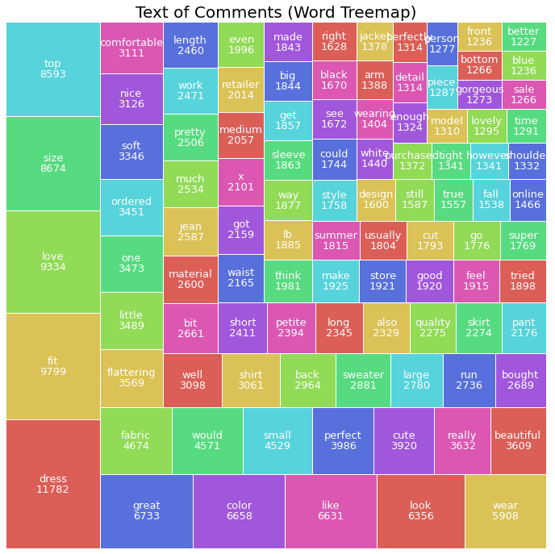

```python
top10_frequent = preprocess(df['Text'])[:10]

# bar plot
fig = px.bar(top10_frequent ,
             x = 'Term' ,
             y = 'Frequency' ,
             text = 'Frequency' ,
             color_discrete_sequence = px.colors.sequential.RdBu ,
             title = 'Top 10 frequent terms (bar plot)',
             color = 'Term' ,
             template = 'simple_white')
fig.update_traces(width = 0.7 , marker = dict(line = dict(color = '#000000' , width = 2)))
fig.update_layout(font = dict(size = 17 , family = 'Franklin Gothic'))
fig.show()

frequency_df = preprocess(df['Text'])
create_wordcount_treemap(frequency_df , 'Text of Comments (Word Treemap)' , 100)
```

#### From above, it can be seen that top words are: "dress", "fit", "love"

# 3. Bivariate Analysis

#### Analysis on "relationship of Department between Age and Rate Scores" & "relationship of Rate Scores between Recommended IND

- 1. Whether consumer age would affect buying tendency.
- 2. Explore which departments get high and low Rating score.
- 3. Whether the product recommended get high Rating score.
- 4. Explore what kind of adjectives in review are used in product recommendations.

## 3.1. Department by Age

```python
for i in range(0 , 10):
    df.loc[df['Age'].between(i * 10 , i * 10 + 9 , 'left') , 'age_group'] = '{}-{}'.format(i * 10 , i * 10 + 9)

# 10-19 : bottom(%) , dresses(%) , Intimate(%) , Jackets(%) , Tops(%) , Trend(%)
# 20-29 : bottom(%) , dresses(%) , Intimate(%) , Jackets(%) , Tops(%) , Trend(%)
# ...
# 90-99 : bottom(%) , dresses(%) , Intimate(%) , Jackets(%) , Tops(%) , Trend(%)
age_groups = sorted(df['age_group'].unique())
department_groups = sorted(df['Department Name'].unique())
for i , age_group in enumerate(age_groups):
    age_group_df = df.loc[df['age_group'] == age_group]
    age_department_df = age_group_df.groupby(['Department Name']).apply(lambda x : len(x) / len(age_group_df))
    age_department_df = pd.DataFrame(age_department_df)
    age_department_df['Department Name'] = age_department_df.index
    age_department_df = age_department_df.reset_index(drop = True)

    age_department_df = pd.merge(left = age_group_df , right = age_department_df , on = 'Department Name' , how = 'left')
    age_department_df = age_department_df.rename({0 : 'percentage'} , axis = 1)

    age_department_df = age_department_df[['Department Name' , 'age_group' , 'percentage']]
    age_department_df = age_department_df.drop_duplicates(subset = 'Department Name').reset_index(drop = True)
    if i == 0:
        age_department_df_total = age_department_df
    else:
        age_department_df_total = pd.concat([age_department_df_total , age_department_df] , axis = 0)


age_department_df_total = age_department_df_total.reset_index(drop = True)
def func(x):
    x['scaled_percentage'] =  x['percentage'] / sum(x['percentage'])
    return x
age_department_df_total = age_department_df_total.groupby('Department Name').apply(lambda x: func(x))


department_age_df_list = []
for age in age_groups:
    department_age_df = age_department_df_total.loc[age_department_df_total['age_group'] == age].sort_values(by = 'age_group' , ascending = True)
    department_age_df_list.append(department_age_df)

marker_color = ['#67001f','#b2182b','#d6604d','#f4a582','#fddbc7','#d1e5f0','#92c5de','#4393c3','#2166ac']
data = []
for i in range(0 , len(age_groups) - 2):
    data.append(go.Bar(name = age_groups[i] ,
                       x = department_age_df_list[i]['Department Name'] ,
                       y = department_age_df_list[i]['scaled_percentage'] ,
                       text = np.round(department_age_df_list[i]['percentage'] , 2) ,
                       marker_color = marker_color[i]))

fig = go.Figure(data = data)
fig.update_traces(marker = dict(line = dict(color = '#000000' , width = 2)))
fig.update_layout(title ='Department by Age',
                  xaxis_title = 'Department',
                  yaxis_title = 'Aget Percentage',
                  font = dict(size = 17 , family = 'Franklin Gothic') ,
                  template = "simple_white")
fig.show()
```

[interactive chart not shown]

#### Given bar plot above, can observe:

- 1. Younger people prefer to buy Intimate, bottoms and dresses.
- 2. Older people prefer to buy tops and jackets.

## 3.2. Department by Rate

```python
# the percentage of Ration 1 ~ Rating 5 in a department
# Jacket and bottoms both have high ratings, with few low ratings, while the trends have few high ratings and many low ratings.
# bottoms : Rating 1(%) , Rating 2(%) , Rating 3(%) , Rating 4(%) , Rating 5(%) , Rating 6(%)
# dresses : Rating 1(%) , Rating 2(%) , Rating 3(%) , Rating 4(%) , Rating 5(%) , Rating 6(%)
# ...
# Trend   : Rating 1(%) , Rating 2(%) , Rating 3(%) , Rating 4(%) , Rating 5(%) , Rating 6(%)
# Jacket and bottoms both have high ratings, with few low ratings, while the trends have few high ratings and many low ratings.
rating_groups = sorted(df['Rating'].unique())
department_groups = sorted(df['Department Name'].unique())
for i , department_group in enumerate(department_groups):
    department_group_df = df.loc[df['Department Name'] == department_group]
    rating_department_df = department_group_df.groupby(['Rating']).apply(lambda x : len(x) / len(department_group_df))
    rating_department_df = pd.DataFrame(rating_department_df)
    rating_department_df['Rating'] = rating_department_df.index
    rating_department_df = rating_department_df.reset_index(drop = True)

    rating_department_df = pd.merge(left = department_group_df , right = rating_department_df , on = 'Rating' , how = 'left')
    rating_department_df = rating_department_df.rename({0 : 'percentage'} , axis = 1)

    rating_department_df =rating_department_df[['Department Name' , 'Rating' , 'percentage']]
    rating_department_df = rating_department_df.drop_duplicates(subset = 'Rating').reset_index(drop = True)
    if i == 0:
        rating_department_df_total = rating_department_df
    else:
        rating_department_df_total = pd.concat([rating_department_df_total , rating_department_df] , axis = 0)


department_rating_df_list = []
for rating in rating_groups:
    department_rating_df = rating_department_df_total.loc[rating_department_df_total['Rating'] == rating]
    department_rating_df['Rating'] = department_rating_df['Rating'].astype(str)
    department_rating_df_list.append(department_rating_df)


marker_color = ['#67001f','#b2182b','#d6604d','#f4a582','#fddbc7','#d1e5f0','#92c5de','#4393c3','#2166ac']
data = []
for i in range(0 , len(rating_groups)):
    data.append(go.Bar(name = str(rating_groups[i]) ,
                       x = department_rating_df_list[i]['Department Name'] ,
                       y = department_rating_df_list[i]['percentage'] ,
                       text = np.round(department_rating_df_list[i]['percentage'] , 2) ,
                       marker_color = marker_color[i]))

fig = go.Figure(data = data)
fig.update_traces(marker = dict(line = dict(color = '#000000' , width = 2)))
fig.update_layout(title ='Department by Rating',
                  xaxis_title = 'Department',
                  yaxis_title = 'Rating Percentage',
                  font = dict(size = 17 , family = 'Franklin Gothic') ,
                  template = "simple_white")
fig.show()
```

[interactive chart not shown]

## 3.3. Recommended IND by Rate

```python
# 1 : Rating 1(%) , Rating 2(%) , Rating 3(%) , Rating 4(%) , Rating 5(%) , Rating 6(%)
# 0 : Rating 1(%) , Rating 2(%) , Rating 3(%) , Rating 4(%) , Rating 5(%) , Rating 6(%)
recommend_groups = sorted(df['Recommended IND'].unique())
rating_groups = sorted(df['Rating'].unique())
for i , recommend_group in enumerate(recommend_groups):
    recommend_group_df = df.loc[df['Recommended IND'] == recommend_group]
    rating_recommend_df = recommend_group_df.groupby(['Rating']).apply(lambda x : len(x) / len(recommend_group_df))
    rating_recommend_df = pd.DataFrame(rating_recommend_df)
    rating_recommend_df['Rating'] = rating_recommend_df.index
    rating_recommend_df = rating_recommend_df.reset_index(drop = True)

    rating_recommend_df = pd.merge(left = recommend_group_df , right = rating_recommend_df , on = 'Rating' , how = 'left')
    rating_recommend_df = rating_recommend_df.rename({0 : 'percentage'} , axis = 1)

    rating_recommend_df = rating_recommend_df[['Recommended IND' , 'Rating' , 'percentage']]
    rating_recommend_df = rating_recommend_df.drop_duplicates(subset = 'Rating').reset_index(drop = True)
    if i == 0:
        rating_recommend_df_total = rating_recommend_df
    else:
        rating_recommend_df_total = pd.concat([rating_recommend_df_total , rating_recommend_df] , axis = 0)

recommend_rating_df_list = []
for rating in rating_groups:
    recommend_rating_df = rating_recommend_df_total.loc[rating_recommend_df_total['Rating'] == rating]
    recommend_rating_df['Rating'] = recommend_rating_df['Rating'].astype(str)
    recommend_rating_df_list.append(recommend_rating_df)

marker_color = ['#67001f','#b2182b','#d6604d','#f4a582','#fddbc7','#d1e5f0','#92c5de','#4393c3','#2166ac']
data = []
for i in range(0 , len(rating_groups)):
    data.append(go.Bar(name = str(rating_groups[i]) ,
                       x = recommend_rating_df_list[i]['Recommended IND'] ,
                       y = recommend_rating_df_list[i]['percentage'] ,
                       text = np.round(recommend_rating_df_list[i]['percentage'] , 2) ,
                       marker_color = marker_color[i]))

fig = go.Figure(data = data)
fig.update_traces(marker = dict(line = dict(color = '#000000' , width = 2)))
fig.update_layout(title ='Recommended IND by Rating',
                  xaxis_title = 'Recommended IND',
                  yaxis_title = 'Rating Percentage',
                  font = dict(size = 17 , family = 'Franklin Gothic') ,
                  template = "simple_white")
fig.show()
```

[interactive chart not shown]

#### Given bar plot above, can observe

- 1. With a recommended IND of 1, the majority of rating scores distributed on 4 and 5.
- 2. With a recommended IND of 0, the majority of rating scores distributed on 1, 2 and 3.

## 3.4. Text by Recommended IND (Positive Adjectives)

```python
def preprocess_adj(column):
    all_str = get_all_str(column)
    words = get_word(all_str)
    words_remove_stopword = remove_stopword(words)
    words_lemmatize = lemmatization(words_remove_stopword)
    word_tagged = nltk.pos_tag(words_lemmatize)
    words_adj = pos_adjective(word_tagged)
    frequency_df = freq_df(words_adj)
    return frequency_df

recommended_p = df[df['Recommended IND'] == 1]
df_freq_adj_p  = preprocess_adj(recommended_p['Text'])
top10_frequent_p = df_freq_adj_p[:10]

# bar plot
fig = px.bar(top10_frequent_p ,
             x = 'Term' ,
             y = 'Frequency' ,
             text = 'Frequency' ,
             color_discrete_sequence = px.colors.sequential.RdBu ,
             title = 'Top 10 frequent recommended terms (bar plot)',
             color = 'Term' ,
             template = 'simple_white')
fig.update_traces(width = 0.7 , marker = dict(line = dict(color = '#000000' , width = 2)))
fig.update_layout(font = dict(size = 17 , family = 'Franklin Gothic'))
fig.show()
```

[interactive chart not shown]

#### Recommended comments largely contain positive terms such as 'great', 'fit', 'comfortable' 'beautiful', and 'nice'.

# 4. Text Preprocessing

## 4.1. Define Preprocessing Function

```python
def preprocess(column):
    all_str = get_all_str(column)
    words = get_word(all_str)
    words_remove_stopword = remove_stopword(words)
    words_lemmatize = lemmatization(words_remove_stopword)
    return words_lemmatize

df.to_csv('df_no_missing.csv')
df = pd.read_csv('./df_no_missing.csv')
df['Text'] = df.apply(lambda x : preprocess(x['Text']) , axis = 1)
df.to_csv('df_cleaning.csv')
```

```python
df = pd.read_csv('./df_cleaning.csv')
y = df['Recommended IND']
X = df.drop('Recommended IND' , axis = 1)
X['Text'] = X['Text'].apply(lambda x : eval(x))

# hyperparameter
batch_size = 128
epochs = 10

# split by ratio of 0.3
X_train , X_test , y_train , y_test = train_test_split(X['Text'] , y , test_size = 0.3 , random_state = 0)
```

## 4.2. Tokenization, Sequencing and Padding

```python
tokenizer = BertTokenizer.from_pretrained('bert-base-uncased')
```

```python
seq_max_len = max(X['Text'].apply(lambda x : len(x)))

X_train_text = tokenizer(list(X_train) ,
                         is_split_into_words = True ,
                         padding = True ,
                         truncation=True ,
                         max_length = seq_max_len ,
                         return_tensors = "tf")

X_test_text = tokenizer(list(X_test) ,
                        is_split_into_words = True ,
                        padding = True ,
                        truncation = True ,
                        max_length = seq_max_len ,
                        return_tensors = "tf")

y_train , y_test = np.array(y_train.astype(np.int32)) , np.array(y_test.astype(np.int32))
```

[output not shown]

# 5. Text Classification (BERT Model)

## 5.1. Define Model

- 1. use BERT & bert-base-uncased(#params 110M)
- 2. use Fine-Tuning & Classfication Model.

```python
bert_model = TFBertForSequenceClassification.from_pretrained('bert-base-uncased' , num_labels = 2)
optimizer = tf.keras.optimizers.Adam(learning_rate = 1e-5)
```

```
All PyTorch model weights were used when initializing TFBertForSequenceClassification.

Some weights or buffers of the TF 2.0 model TFBertForSequenceClassification were not initialized from the PyTorch model and are newly initialized: ['classifier.weight', 'classifier.bias']
You should probably TRAIN this model on a down-stream task to be able to use it for predictions and inference.
```

## 5.2. Train Model

```python
def minibatch_index(minibatch_num , len_data , training = True):
    total_index = list(range(0 , len_data))
    if training == True:
        random.shuffle(total_index)

    step = (int(len_data / minibatch_num) + 1) * minibatch_num
    temp = []
    index = []
    j = 0
    for ii in range(0 , step):
        j = j + 1
        if j > len_data:
            j = j - (len_data)
        temp.append([total_index[j - 1]])
        if len(temp) == minibatch_num:
            index.append(temp)
            temp = []
    return index


train_index_list = minibatch_index(minibatch_num = batch_size , len_data = len(X_train))
test_index_list = minibatch_index(minibatch_num = 1 , len_data = len(X_test) , training = False)


@tf.function
def train_step(x , y):
    with tf.GradientTape() as tape:
        bert_output = bert_model(x)
        prediction = tf.nn.softmax(bert_output.logits , axis = -1)
        y_pred = prediction[: , 1]
        y_pred = tf.reshape(y_pred , [-1 , 1])

        prediction = tf.math.log(tf.clip_by_value(prediction , 1e-8 , tf.reduce_max(prediction)))
        y_onehot = tf.one_hot(y , depth = 2)
        cross_entropy_temp = -tf.reduce_sum(y_onehot * prediction , axis = 1)
        cross_entropy = tf.reduce_mean(cross_entropy_temp)
        correct = tf.equal(tf.math.argmax(prediction , 1) , tf.argmax(y_onehot , 1))
        correct = tf.cast(correct , tf.float32)
        accuracy = tf.reduce_mean(correct)
    var_list = [var for var in bert_model.trainable_variables]
    grads = tape.gradient(cross_entropy , var_list)
    optimizer.apply_gradients(grads_and_vars = zip(grads , var_list))
    return cross_entropy , accuracy , y_pred

@tf.function
def test_step(x , y):
    bert_output = bert_model(x)
    prediction = tf.nn.softmax(bert_output.logits , axis = -1)
    y_pred = prediction[: , 1]
    y_pred = tf.reshape(y_pred , [-1 , 1])

    prediction = tf.math.log(tf.clip_by_value(prediction , 1e-8 , tf.reduce_max(prediction)))
    y_onehot = tf.one_hot(tf.reshape(y , [-1 , ]) , depth = 2)
    cross_entropy_temp = -tf.reduce_sum(y_onehot * prediction , axis = 1)
    cross_entropy = tf.reduce_mean(cross_entropy_temp)
    return cross_entropy , y_pred


auc_acc_loss_history = {'train':{'loss':{} , 'acc':{} , 'auc':{}} , 'test' :{'loss':{} , 'acc':{} , 'auc':{}}}
for epoch_i in range(0 , epochs):

    # trining
    loss_train = 0
    accuracy_train = 0
    auc_train = 0
    for batch_i , index in enumerate(train_index_list):
        x_train_batch = {'input_ids': tf.gather_nd(X_train_text['input_ids'] , indices = index) ,
                         'attention_mask': tf.gather_nd(X_train_text['attention_mask'] , indices = index)}
        y_train_batch = y_train[np.squeeze(np.array(index))]

        loss_train_batch , acc_train_batch , y_pred_train_batch = train_step(x_train_batch , y_train_batch)
        loss_train += loss_train_batch.numpy()
        accuracy_train += acc_train_batch.numpy()
        auc_train += roc_auc_score(y_train_batch , y_pred_train_batch.numpy())

    loss_train /= len(train_index_list)
    accuracy_train /= len(train_index_list)
    auc_train /= len(train_index_list)

    # testing
    loss_test = 0
    y_test_list = []
    y_pred_test_list = []
    for batch_i , index in enumerate(test_index_list):
        x_test_batch = {'input_ids': tf.gather_nd(X_test_text['input_ids'] , indices = index) ,
                        'attention_mask': tf.gather_nd(X_test_text['attention_mask'] , indices = index)}
        y_test_batch = y_test[np.squeeze(np.array(index))]

        loss_test_batch , y_pred_test_batch = test_step(x_test_batch , y_test_batch)
        loss_test += loss_train_batch.numpy()
        y_test_list.append(y_test_batch.astype(float))
        y_pred_test_list.append(y_pred_test_batch.numpy())

    loss_test /= len(test_index_list)
    accuracy_test  = accuracy_score(np.reshape(np.array(y_test_list) , [-1 , ]) , (np.reshape(np.array(y_pred_test_list), [-1 , ]) > 0.5).astype(np.float32))
    auc_test = roc_auc_score(np.reshape(np.array(y_test_list) , [-1 , ]) , np.reshape(np.array(y_pred_test_list), [-1 , ]))

    print('=' * 83)
    print('epoch_i : {} , train_loss : {:.4f} , train_accuracy : {:.2%} , train_auc : {:.4f}'.format(epoch_i+1 , loss_train , accuracy_train , auc_train))
    auc_acc_loss_history['train']['loss'][epoch_i + 1] = loss_train
    auc_acc_loss_history['train']['acc'][epoch_i + 1] = accuracy_train
    auc_acc_loss_history['train']['auc'][epoch_i + 1] = auc_train
    print('epoch_i : {} , test_loss : {:.4f} , test_accuracy : {:.2%} , test_auc : {:.4f}'.format(epoch_i+1 , loss_test , accuracy_test , auc_test))
    auc_acc_loss_history['test']['loss'][epoch_i + 1] = loss_test
    auc_acc_loss_history['test']['acc'][epoch_i + 1] = accuracy_test
    auc_acc_loss_history['test']['auc'][epoch_i + 1] = auc_test

    bert_model.save_weights('bert_model/epoch_{}/'.format(epoch_i + 1))

bert_save = {'X_train_text'  : X_train_text ,
             'X_test_text'   : X_test_text ,
             'y_train'  : y_train ,
             'y_test'   : y_test,
             'auc_acc_loss_history' : auc_acc_loss_history}

with open('bert_save.pkl', 'wb') as f:
    pickle.dump(bert_save , f)
```

```
===================================================================================
epoch_i : 1 , train_loss : 0.3473 , train_accuracy : 85.93% , train_auc : 0.8488
epoch_i : 1 , test_loss : 0.2440 , test_accuracy : 90.66% , test_auc : 0.9471
===================================================================================
epoch_i : 2 , train_loss : 0.1929 , train_accuracy : 92.22% , train_auc : 0.9618
epoch_i : 2 , test_loss : 0.1350 , test_accuracy : 90.51% , test_auc : 0.9513
===================================================================================
epoch_i : 3 , train_loss : 0.1332 , train_accuracy : 95.01% , train_auc : 0.9805
epoch_i : 3 , test_loss : 0.0752 , test_accuracy : 90.14% , test_auc : 0.9470
===================================================================================
epoch_i : 4 , train_loss : 0.0991 , train_accuracy : 96.52% , train_auc : 0.9912
epoch_i : 4 , test_loss : 0.0618 , test_accuracy : 90.64% , test_auc : 0.9377
===================================================================================
epoch_i : 5 , train_loss : 0.0729 , train_accuracy : 97.37% , train_auc : 0.9954
epoch_i : 5 , test_loss : 0.0565 , test_accuracy : 90.25% , test_auc : 0.9295
===================================================================================
epoch_i : 6 , train_loss : 0.0555 , train_accuracy : 98.13% , train_auc : 0.9972
epoch_i : 6 , test_loss : 0.0371 , test_accuracy : 90.88% , test_auc : 0.9446
===================================================================================
epoch_i : 7 , train_loss : 0.0332 , train_accuracy : 99.01% , train_auc : 0.9983
epoch_i : 7 , test_loss : 0.0427 , test_accuracy : 89.83% , test_auc : 0.9466
===================================================================================
epoch_i : 8 , train_loss : 0.0196 , train_accuracy : 99.54% , train_auc : 0.9992
epoch_i : 8 , test_loss : 0.0400 , test_accuracy : 91.12% , test_auc : 0.9413
===================================================================================
epoch_i : 9 , train_loss : 0.0098 , train_accuracy : 99.79% , train_auc : 0.9997
epoch_i : 9 , test_loss : 0.0325 , test_accuracy : 91.24% , test_auc : 0.9376
===================================================================================
epoch_i : 10 , train_loss : 0.0070 , train_accuracy : 99.82% , train_auc : 0.9999
epoch_i : 10 , test_loss : 0.0239 , test_accuracy : 91.14% , test_auc : 0.9323
```

## 5.3. Model Inference

- 1. Restore Model
- 2. Compare Each Scores : Accuracy, Precision, Recall, F1, AUC

## 5.3.1. Restore Model

```python
with open('bert_save.pkl', 'rb') as f:
    bert_save = pickle.load(f)

X_train_text , X_test_text , y_train , y_test = bert_save['X_train_text'] , bert_save['X_test_text'] , bert_save['y_train'] , bert_save['y_test']
auc_acc_loss_history = bert_save['auc_acc_loss_history']
del bert_save

bert_model = TFBertForSequenceClassification.from_pretrained('bert-base-uncased')
bert_model.load_weights('bert_model/epoch_8/')
```

[output not shown]

```
<tensorflow.python.checkpoint.checkpoint.CheckpointLoadStatus at 0x7f72e0417040>
```

## 5.3.2. Compare Each Scores : Accuracy, Precision, Recall, F1, AUC

```python
@tf.function
def inference(x , y):
    bert_output = bert_model(x)
    prediction = tf.nn.softmax(bert_output.logits , axis = -1)
    y_pred = prediction[: , 1]
    y_pred = tf.reshape(y_pred , [-1 , 1])

    prediction = tf.math.log(tf.clip_by_value(prediction , 1e-8 , tf.reduce_max(prediction)))
    y_onehot = tf.one_hot(tf.reshape(y , [-1 , ]) , depth = 2)
    cross_entropy_temp = -tf.reduce_sum(y_onehot * prediction , axis = 1)
    cross_entropy = tf.reduce_mean(cross_entropy_temp)
    return cross_entropy , y_pred

def minibatch_index(minibatch_num , len_data , training = True):
    total_index = list(range(0 , len_data))
    if training == True:
        random.shuffle(total_index)

    step = (int(len_data / minibatch_num) + 1) * minibatch_num
    temp = []
    index = []
    j = 0
    for ii in range(0 , step):
        j = j + 1
        if j > len_data:
            j = j - (len_data)
        temp.append([total_index[j - 1]])
        if len(temp) == minibatch_num:
           index.append(temp)
           temp = []
    return index

train_index_list = minibatch_index(minibatch_num = 1 , len_data = len(y_train) , training = False)
test_index_list = minibatch_index(minibatch_num = 1 , len_data = len(y_test) , training = False)
```

```python
y_train_list = []
y_pred_train_list = []
for batch_i , index in enumerate(train_index_list):
    x_train_batch = {'input_ids': tf.gather_nd(X_train_text['input_ids'] , indices = index) ,
                     'attention_mask': tf.gather_nd(X_train_text['attention_mask'] , indices = index)}
    y_train_batch = y_train[np.squeeze(np.array(index))]

    _ , y_pred_train_batch = inference(x_train_batch , y_train_batch)
    y_train_list.append(y_train_batch.astype(float))
    y_pred_train_list.append(y_pred_train_batch.numpy())

# train probability
y_pred_train_list = np.reshape(np.array(y_pred_train_list), [-1 , ])

# train predicted label
y_pred_train_list_label = np.round(y_pred_train_list)


# list of train metrics scores
accuracy  = accuracy_score(np.reshape(np.array(y_train_list) , [-1 , ]) , y_pred_train_list_label)
precision = precision_score(np.reshape(np.array(y_train_list) , [-1 , ]) , y_pred_train_list_label)
recall = recall_score(np.reshape(np.array(y_train_list) , [-1 , ]) , y_pred_train_list_label)
f1 = f1_score(np.reshape(np.array(y_train_list) , [-1 , ]) , y_pred_train_list_label)
AUC = roc_auc_score(np.reshape(np.array(y_train_list) , [-1 , ]) , y_pred_train_list)
train_metrics_list = [accuracy , precision , recall , f1 , AUC]


y_test_list = []
y_pred_test_list = []
for batch_i , index in enumerate(test_index_list):
    x_test_batch = {'input_ids': tf.gather_nd(X_test_text['input_ids'] , indices = index) ,
                    'attention_mask': tf.gather_nd(X_test_text['attention_mask'] , indices = index)}
    y_test_batch = y_test[np.squeeze(np.array(index))]

    _ , y_pred_test_batch = inference(x_test_batch , y_test_batch)
    y_test_list.append(y_test_batch.astype(float))
    y_pred_test_list.append(y_pred_test_batch.numpy())

# test probability
y_pred_test_list = np.reshape(np.array(y_pred_test_list), [-1 , ])

# test predicted label
y_pred_test_list_label = np.round(y_pred_test_list)

# list of test metrics scores
accuracy  = accuracy_score(np.reshape(np.array(y_test_list) , [-1 , ]) , y_pred_test_list_label)
precision = precision_score(np.reshape(np.array(y_test_list) , [-1 , ]) , y_pred_test_list_label)
recall = recall_score(np.reshape(np.array(y_test_list) , [-1 , ]) , y_pred_test_list_label)
f1 = f1_score(np.reshape(np.array(y_test_list) , [-1 , ]) , y_pred_test_list_label)
AUC = roc_auc_score(np.reshape(np.array(y_test_list) , [-1 , ]) , y_pred_test_list)
test_metrics_list = [accuracy , precision , recall , f1 , AUC]

metrics_name = ['Accuracy' , 'Precision' , 'Recall' , 'F1' , 'AUC']
fig = go.Figure(data = [go.Bar(name = 'Train Metrics Scores',
                               x = metrics_name ,
                               y = train_metrics_list ,
                               text = np.round(train_metrics_list , 4) ,
                               marker_color = '#67001f'),

                        go.Bar(name = 'Test Metrics Scores',
                               x = metrics_name ,
                               y = test_metrics_list,
                               text = np.round(test_metrics_list , 4) ,
                               marker_color = '#fddbc7')])

fig.update_traces(width = 0.4 , marker = dict(line = dict(color = '#000000' , width = 2)))
fig.update_layout(xaxis_title = 'Metrics',
                  yaxis_title = 'Metrics scors',
                  font = dict(size = 17 , family = 'Franklin Gothic') ,
                  template = 'simple_white' ,
                  title = 'Train Metrics Scores & Test Metrics Scores')
fig.show()
```

[interactive chart not shown]